# 6 Data visualization

Julia has three reasonable routes to graphics, all resting on [**Makie.jl**](https://docs.makie.org) (Danisch and Krumbiegel 2021):

| Route | For whom |
| --- | --- |
| `TidierPlots.jl` | people coming from `ggplot2` who want the same grammar |
| `AlgebraOfGraphics.jl` | people who want an idiomatically Julian grammar of graphics |
| Plain `Makie.jl` | full control over the figure |

This chapter shows all three on the same data, because the right choice depends on the task — and because knowing how to translate between them keeps you from getting stuck.

```julia
using TidierData
using CairoMakie
using AlgebraOfGraphics
using CSV, DataFrames

CairoMakie.activate!(type = "png")

ponds = CSV.read(joinpath("..", "data", "ponds.csv"), DataFrame)
ponds_c = @chain ponds begin
    @drop_missing(canopy)
    @mutate(log_area = log(area_m2))
end

nrow(ponds_c)
```

```
173
```

**NoteExercises in this chapter**

A figure cannot be checked automatically, so in most *Your turn* boxes you compare your plot with the one in the solution. Start each session by loading the packages and the data, with the book folder open in VS Code:

```julia
include("exercises/check.jl")
using TidierData, TidierPlots, CairoMakie, AlgebraOfGraphics, CSV, DataFrames, Statistics
ponds = CSV.read(joinpath("data", "ponds.csv"), DataFrame)
ponds_c = @chain ponds begin
    @drop_missing(canopy)
    @mutate(log_area = log(area_m2))
end
```

## 6.1 `TidierPlots.jl`: the ggplot grammar

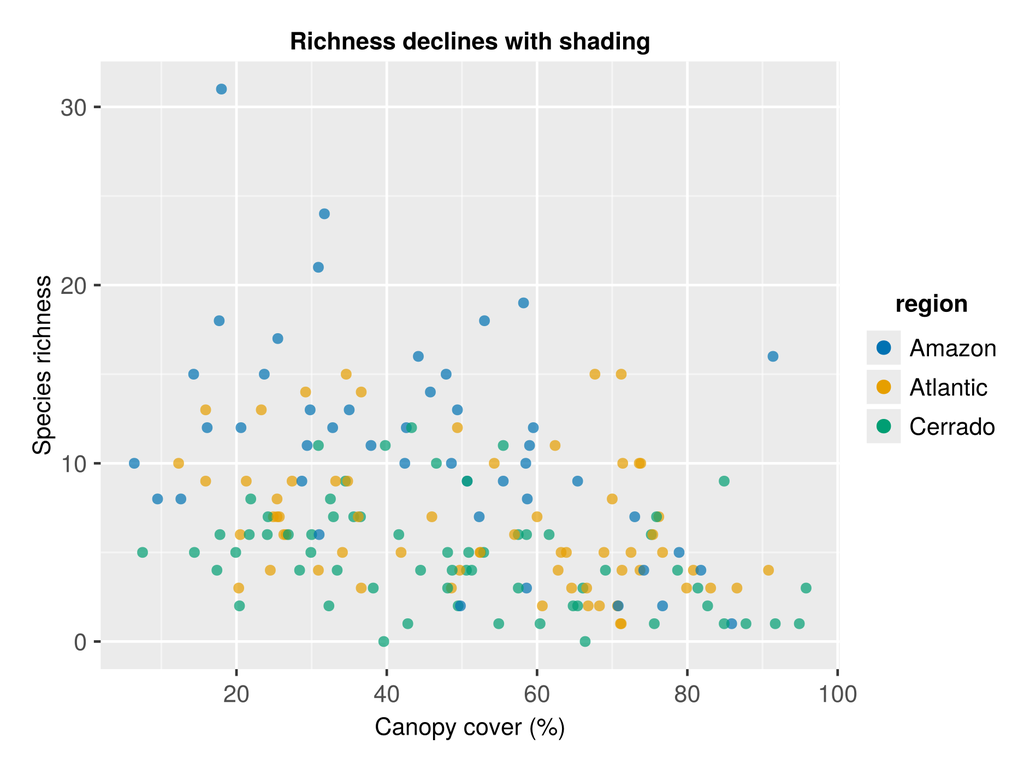

Figure 6.1: Richness against canopy cover, by region.

```julia
using TidierPlots

ggplot(ponds_c, @aes(x = canopy, y = richness, color = region)) +
    geom_point(alpha = 0.7) +
    labs(x = "Canopy cover (%)", y = "Species richness",
         title = "Richness declines with shading")
```

**In R**

```r
ggplot(ponds_c, aes(x = canopy, y = richness, colour = region)) +
  geom_point(alpha = 0.7) +
  labs(x = "Canopy cover (%)", y = "Species richness")
```

The translation is nearly character for character; the difference is the `@` in `@aes`.

**NoteYour turn 6.1 — Richness and temperature**

Redo Figure 6.1 with water temperature (`temp_c`) on the x axis and the points coloured by hydroperiod (`hydro`). Label both axes. Does richness change with temperature as clearly as with canopy?

There is no checker for this one: compare your figure with the one in the solution.

**TipHint**

Only the `@aes` mapping and the labels change.

**CautionSolution**

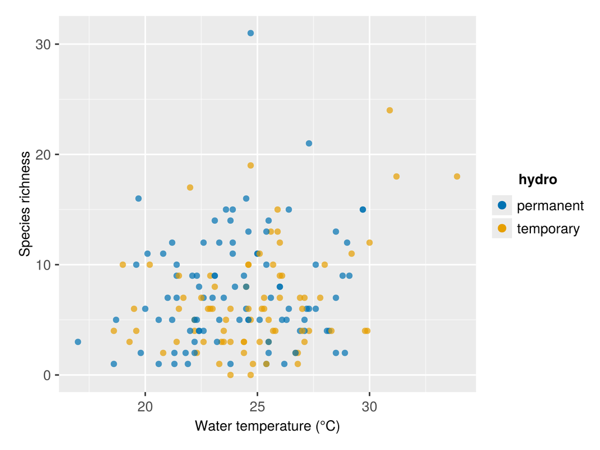

```julia
ggplot(ponds_c, @aes(x = temp_c, y = richness, color = hydro)) +
    geom_point(alpha = 0.7) +
    labs(x = "Water temperature (°C)", y = "Species richness")
```

The cloud is much flatter than for canopy. The simulation does include a temperature effect (`scripts/make_data.jl`), but a small one: about 3% more species per degree, invisible next to the scatter between ponds.

## 6.2 `AlgebraOfGraphics.jl`: an algebraic grammar

AoG treats plots as an algebra: `*` combines layers, `+` superimposes them.

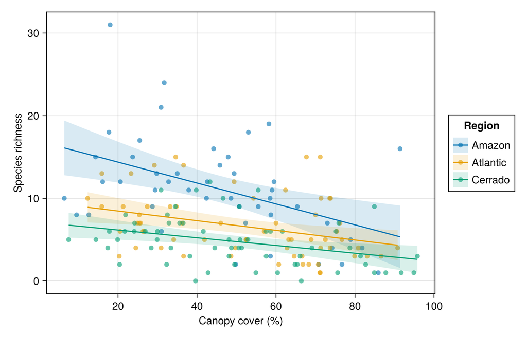

Figure 6.2: The same plot in AlgebraOfGraphics, with a linear fit per region.

```julia
plt = AlgebraOfGraphics.data(ponds_c) *
      mapping(:canopy => "Canopy cover (%)",
              :richness => "Species richness",
              color = :region => "Region") *
      (visual(Scatter, alpha = 0.6) + AlgebraOfGraphics.linear())

draw(plt; figure = (size = (700, 450),))
```

**Note**

`AlgebraOfGraphics.data` and `AlgebraOfGraphics.linear` are qualified because the names `data` and `linear` collide with other loaded packages. In a script using only AoG, `data(...)` and `linear()` suffice.

**NoteYour turn 6.2 — Body size, with fitted lines**

With AlgebraOfGraphics, plot `body_size` against `temp_c`, coloured by `hydro`, with a linear fit for each hydroperiod. Do permanent and temporary ponds differ?

There is no checker for this one: compare your figure with the one in the solution.

**TipHint**

Start from the block above and change the `mapping`. The fitted lines follow the colour grouping automatically.

**CautionSolution**

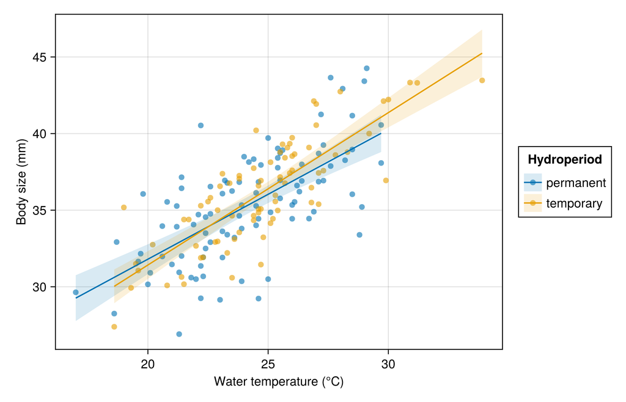

```julia
plt = AlgebraOfGraphics.data(ponds_c) *
      mapping(:temp_c => "Water temperature (°C)",
              :body_size => "Body size (mm)",
              color = :hydro => "Hydroperiod") *
      (visual(Scatter, alpha = 0.6) + AlgebraOfGraphics.linear())

draw(plt; figure = (size = (700, 450),))
```

The two lines almost coincide: in the simulation, body size depends on temperature and canopy but not on hydroperiod. We test this formally in Chapter 7.

## 6.3 Facets

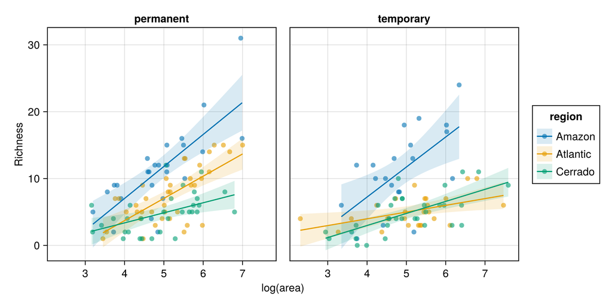

Figure 6.3: Richness–area relationship faceted by hydroperiod.

```julia
plt = AlgebraOfGraphics.data(ponds_c) *
      mapping(:log_area => "log(area)",
              :richness => "Richness",
              color = :region,
              layout = :hydro) *
      (visual(Scatter, alpha = 0.6) + AlgebraOfGraphics.linear())

draw(plt; figure = (size = (800, 400),))
```

**NoteYour turn 6.3 — Facets in the ggplot grammar**

Translate Figure 6.3 to `TidierPlots.jl`, using `facet_wrap` to split the panels by hydroperiod. Leave out the fitted lines (see the warning in the solution).

There is no checker for this one: compare your figure with the one in the solution.

**TipHint**

`facet_wrap(facets = :hydro)` is added with `+`, like any other layer.

**CautionSolution**

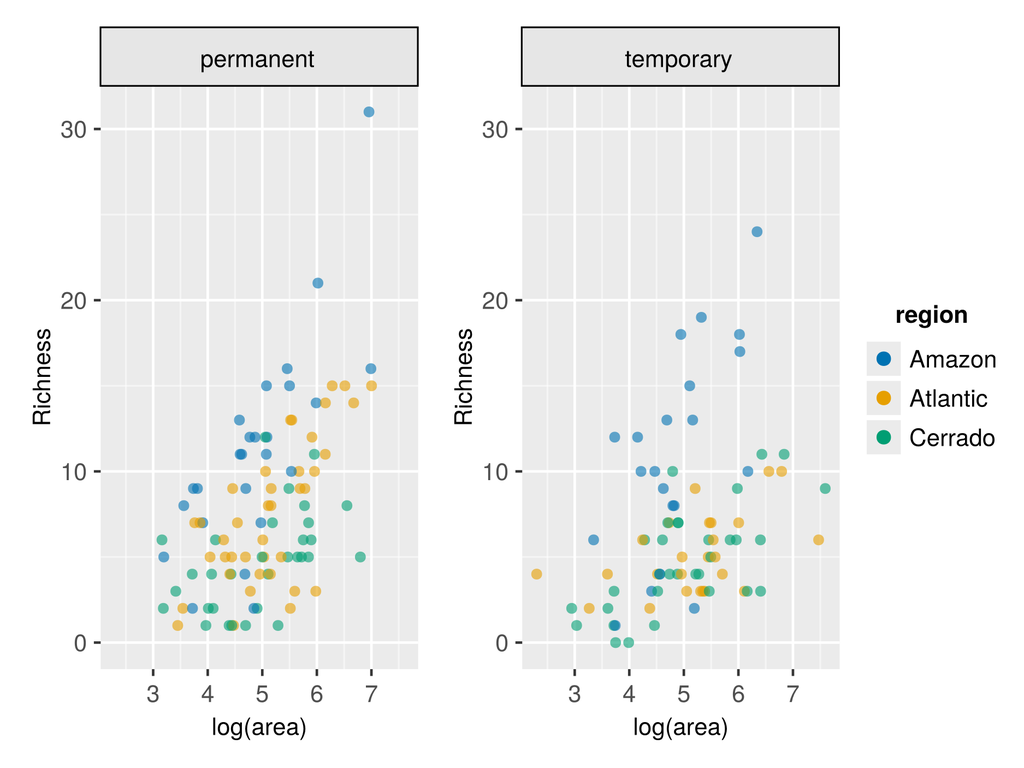

```julia
ggplot(ponds_c, @aes(x = log_area, y = richness, color = region)) +
    geom_point(alpha = 0.6) +
    facet_wrap(facets = :hydro) +
    labs(x = "log(area)", y = "Richness")
```

**WarningA limit of TidierPlots**

In `TidierPlots.jl` 1.0.0 (checked in September 2026), adding `geom_smooth(method = "lm")` to a faceted plot fails with `column name :facet not found`. `geom_smooth` works without facets, and facets work without `geom_smooth`, but not together. When the ggplot grammar reaches a limit like this, AlgebraOfGraphics (Figure 6.3) is the way out.

## 6.4 Distributions

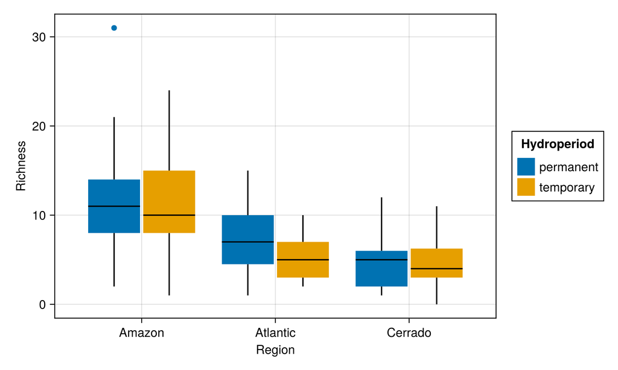

Figure 6.4: Richness distribution by region and hydroperiod.

```julia
plt = AlgebraOfGraphics.data(ponds_c) *
      mapping(:region => "Region",
              :richness => "Richness",
              color = :hydro => "Hydroperiod",
              dodge = :hydro) *
      visual(BoxPlot)

draw(plt; figure = (size = (700, 420),))
```

**NoteYour turn 6.4 — The shape of a distribution**

Boxplots hide the shape of a distribution. Show the distribution of `body_size` in each region as violins (`Violin`), with one colour per region.

There is no checker for this one: compare your figure with the one in the solution.

**TipHint**

Replace `BoxPlot` with `Violin` and map `region` to both the x axis and `color`.

**CautionSolution**

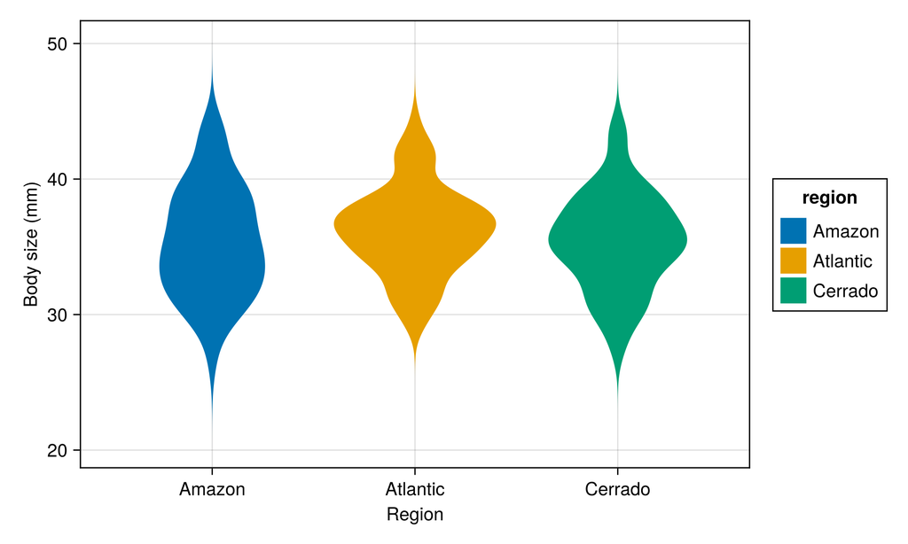

```julia
plt = AlgebraOfGraphics.data(ponds_c) *
      mapping(:region => "Region",
              :body_size => "Body size (mm)",
              color = :region) *
      visual(Violin)

draw(plt; figure = (size = (700, 420),))
```

## 6.5 Plain `Makie.jl`: full control

When a figure needs a layout the grammar cannot express, drop down to Makie.

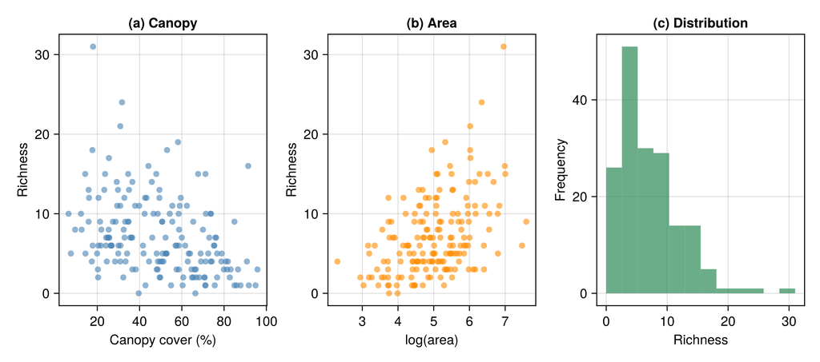

Figure 6.5: A composite figure assembled by hand with Makie.

```julia
fig = Figure(size = (860, 380))

ax1 = Axis(fig[1, 1], xlabel = "Canopy cover (%)", ylabel = "Richness",
           title = "(a) Canopy")
scatter!(ax1, ponds_c.canopy, ponds_c.richness, color = (:steelblue, 0.6))

ax2 = Axis(fig[1, 2], xlabel = "log(area)", ylabel = "Richness",
           title = "(b) Area")
scatter!(ax2, ponds_c.log_area, ponds_c.richness, color = (:darkorange, 0.6))

ax3 = Axis(fig[1, 3], xlabel = "Richness", ylabel = "Frequency",
           title = "(c) Distribution")
hist!(ax3, ponds_c.richness, bins = 12, color = (:seagreen, 0.7))

fig
```

Makie’s layout system is grid-based (`fig[row, col]`), covering the role of `patchwork` and `cowplot` in R without an extra package.

**NoteYour turn 6.5 — Two panels by hand**

Build a figure with `size = (800, 350)` and two panels: on the left, a boxplot of richness by region; on the right, a bar chart of the proportion of ponds with the focal species in each region (the numbers from 5.4). Store it in `fig_regions`.

There is no checker for this one: compare your figure with the one in the solution.

**TipHint**

Makie’s `boxplot!` and `barplot!` want numbers on the x axis. Give each region a number with `[findfirst(==(r), regs) for r in ponds.region]`, where `regs = ["Amazon", "Atlantic", "Cerrado"]`, and put the names back with `xticks = (1:3, regs)` in each `Axis`.

**CautionSolution**

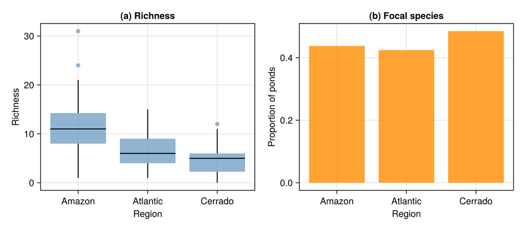

```julia
regs = ["Amazon", "Atlantic", "Cerrado"]
idx = [findfirst(==(r), regs) for r in ponds.region]
props = [mean(ponds.focal[ponds.region .== r]) for r in regs]

fig_regions = Figure(size = (800, 350))

ax1 = Axis(fig_regions[1, 1], xticks = (1:3, regs),
           xlabel = "Region", ylabel = "Richness", title = "(a) Richness")
boxplot!(ax1, idx, ponds.richness, color = (:steelblue, 0.6))

ax2 = Axis(fig_regions[1, 2], xticks = (1:3, regs),
           xlabel = "Region", ylabel = "Proportion of ponds", title = "(b) Focal species")
barplot!(ax2, 1:3, props, color = (:darkorange, 0.8))

fig_regions
```

The two panels tell different stories: richness differs sharply between regions, focal-species occurrence hardly at all.

## 6.6 Saving figures

```julia
save("figure.png", fig; px_per_unit = 3)   # high-resolution raster
save("figure.pdf", fig)                    # vector, for publication
save("figure.svg", fig)
```

**NoteYour turn 6.6 — A figure for publication**

Save `fig_regions` from 6.5 as `focal-by-region.png`, at three pixels per unit, in the book folder. Then check the file: `check("6.6", "focal-by-region.png")`.

**TipHint**

The block above shows the keyword that sets the resolution.

**CautionSolution**

```julia
save("focal-by-region.png", fig_regions; px_per_unit = 3)
check("6.6", "focal-by-region.png")
```

An 800 × 350 figure at three pixels per unit gives a 2400 × 1050 px image — enough for a two-column journal figure. For vector output, save as `.pdf` instead.

**TipChoosing a backend**

`CairoMakie` produces publication-quality static output (PNG, PDF, SVG) and is what this book uses. `GLMakie` opens GPU-accelerated interactive windows — useful for exploring data, unsuitable for rendering a book.

## Challenges

1. In 6.1 you judged the temperature effect by eye. Add a linear fit per hydroperiod with `geom_smooth(method = "lm")`. Does the line change your reading of the plot? What would you need to know before trusting it?
2. Panel (b) of 6.5 shows proportions without uncertainty. Add an error bar of $\pm 2$ standard errors to each bar, with $\text{SE} = \sqrt{p(1-p)/n}$ and `errorbars!`. Do the regions still look different?
3. Redo Figure 6.5 with one colour per region in every panel and a single shared legend on the right (`Legend(fig[1, 4], ...)`).

Danisch, Simon, and Julius Krumbiegel. 2021. “Makie.jl: Flexible high-performance data visualization for Julia.” *Journal of Open Source Software* 6 (65): 3349. https://doi.org/10.21105/joss.03349.